# Google Career Certificate: Cyclist bike share 2021

#### From_Station

```r
#station (total)
     year_2021_df_7 %>%
      group_by(from_station_name) %>%
      summarize(mean(time_duration)) %>%
       print(n=1000)
```

##### Results

```r
# A tibble: 836 × 2
   from_station_name          `mean(time_duration)`
   <chr>                                      <dbl>
 1 2112 w peterson ave                         20.1
 2 63rd st beach                               60.4
 3 900 w harrison st                           14.6
 4 aberdeen st & jackson blvd                  14.0
 5 aberdeen st & monroe st                     19.1
 6 aberdeen st & randolph st                   18.0
 7 ada st & 113th st                           24.6
 8 ada st & washington blvd                    14.6
 9 adler planetarium                           34.0
10 albany ave & 26th st                        27.2
# … with 826 more rows
# ℹ Use `print(n = ...)` to see more rows
```

```r
#station (user-type)
     year_2021_df_7 %>%
       group_by(usertype,from_station_name) %>%
       summarize(mean(time_duration)) %>%
       print(n=2000)
```

##### Results

```r
# A tibble: 1,637 × 3
# Groups:   usertype [2]
   usertype from_station_name          `mean(time_duration)`
   <chr>    <chr>                                      <dbl>
 1 casual   2112 w peterson ave                         23.6
 2 casual   63rd st beach                               84.3
 3 casual   900 w harrison st                           24.0
 4 casual   aberdeen st & jackson blvd                  21.2
 5 casual   aberdeen st & monroe st                     34.1
 6 casual   aberdeen st & randolph st                   27.3
 7 casual   ada st & 113th st                           34.6
 8 casual   ada st & washington blvd                    19.2
 9 casual   adler planetarium                           40.9
10 casual   albany ave & 26th st                        32.8
# … with 1,627 more rows
# ℹ Use `print(n = ...)` to see more rows
```

##### Visualization

```r
#viz
#Create a data set with top5 start point per each user-type
 top_10_average <-year_2021_df_7 %>%
   group_by(usertype, from_station_name) %>%
   summarise(mean(time_duration))
top_10_average<-top_10_average[order(-top_10_average$`mean(time_duration)`),]#add the , to the end
top_10_average<-top_10_average %>%
  group_by(usertype) %>%
  slice_head(n=5)
```

##### Results

```r
# A tibble: 10 × 3
# Groups:   usertype [2]
    usertype              from_station_name mean(time_duration)
1    casual            throop st & 52nd st          1004.90000
2    casual south chicago ave & elliot ave           948.47059
3    casual      central ave & harrison st           809.73077
4    casual            clyde ave & 87th st           744.34694
5    casual           racine ave & 65th st           650.63158
6    member           pulaski rd & 60th st            84.00000
7    member         western ave & 111th st            56.33333
8    member        michigan ave & 114th st            49.00000
9    member           racine ave & 61st st            48.87500
10   member           cicero ave & lake st            40.80000
```

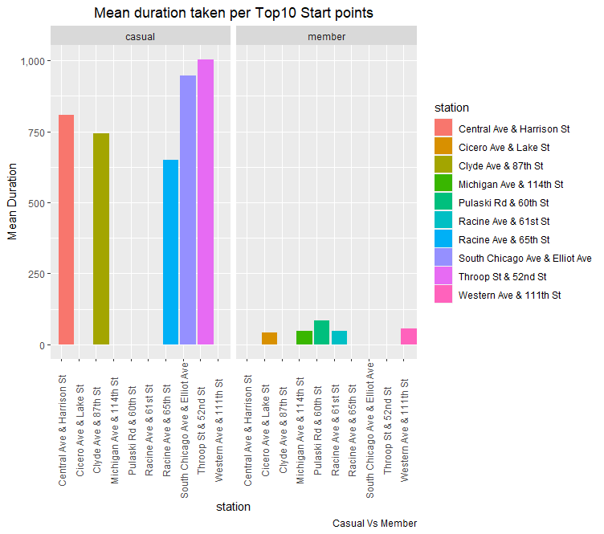

**Average duration taken per Top10 Start points**

```r
#Visualization
ggplot(top_10_average, aes(y=top_10_average$`mean(time_duration)`, x=top_10_average$from_station_name, fill = top_10_average$from_station_name))+
  geom_col(position = position_nudge(x=0.3))+
  labs(title = "Mean duration taken per Top10 Start points",caption = "Casual Vs Member",x="station", y="Mean Duration")+
  theme(plot.title = element_text(hjust = 0.5), axis.text.x = element_text(angle = 90, vjust = 0.5))+ #centering the title
  scale_y_continuous(labels = scales :: comma)+ #removing the E expression
  scale_fill_discrete(name = "station")+ # to change the name of the legend
  facet_grid(~usertype)

#ggsave("Plot18-Average duration taken per Top10 Start points.png")
```

#### Distance taken per each user_type under different factors

#### Distance (General)

```r
#--------------------------Distance(meter)-------------------
max(year_2021_df_7$distance)
min(year_2021_df_7$distance)
mean(year_2021_df_7$distance)
sum(year_2021_df_7$distance)
summary(year_2021_df_7$distance)
```

##### Results

```r
> max(year_2021_df_7$distance)
[1] 20932.4
> min(year_2021_df_7$distance)
[1] 0.51
> mean(year_2021_df_7$distance)
[1] 1510.91
> sum(year_2021_df_7$distance)
[1] 6498336852
> summary(year_2021_df_7$distance)
    Min.  1st Qu.   Median     Mean  3rd Qu.     Max.
    0.51   497.98  1110.52  1510.91  2081.01 20932.40
```

#### Distance (user-type summary)

```r
#summary(user-type)
year_2021_df_7 %>%
  group_by(usertype) %>%
  summarise(first_quartile = as.numeric(quantile(distance,0.25)),
            second_quartile = as.numeric(quantile(distance,0.50)),
            median_time_duration = median(distance),
            mean_time_duration = mean(distance),
            third_quartile = as.numeric(quantile(distance,0.75)),
            IQR = as.numeric(quantile(distance,0.75))-as.numeric(quantile(distance,0.25)),
            #allowed limits so if the values fall outside them they aren't considered as outliers
            max_time_duration = as.numeric(quantile(distance,0.75)) + 1.5*(as.numeric(quantile(distance,0.75))-as.numeric(quantile(distance,0.25))),
            min_time_duration=as.numeric(quantile(distance,0.25))- 1.5*(as.numeric(quantile(distance,0.75))-as.numeric(quantile(distance,0.25))),
            max_time_duration_outlier = max(distance),
            min_time_duration_outlier = min(distance))
```

##### Results

```r
# A tibble: 2 × 11
  usertype first_quartile second_quartile median_time_du…¹ mean_…² third…³   IQR max_t…⁴ min_t…⁵ max_t…⁶ min_t…⁷
  <chr>             <dbl>           <dbl>            <dbl>   <dbl>   <dbl> <dbl>   <dbl>   <dbl>   <dbl>   <dbl>
1 casual             517.           1179.            1179.   1575.   2167. 1651.   4643.  -1959.  20932.    0.51
2 member             487.           1068.            1068.   1462.   2004. 1517.   4279.  -1789.  20104.    0.51
# … with abbreviated variable names ¹median_time_duration, ²mean_time_duration, ³third_quartile,
#   ⁴max_time_duration, ⁵min_time_duration, ⁶max_time_duration_outlier, ⁷min_time_duration_outlier
```

##### Visualization

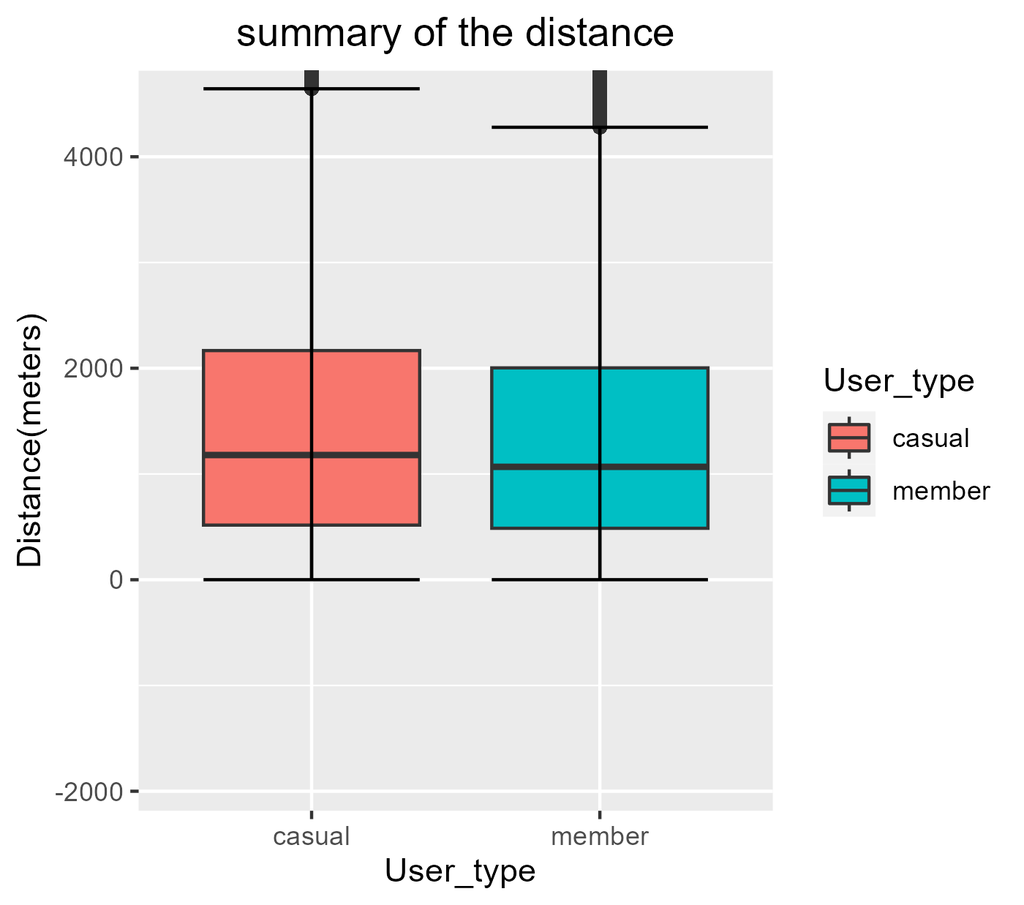

**Statistical summary of the distance of trips for each user type**

```r
#viz
ggplot(year_2021_df_7, mapping = aes(x=usertype, y=distance, fill= usertype))+
  geom_boxplot()+
  stat_boxplot(geom = "errorbar")+
  labs(title = "summary of the distance", x=" User_type", y="Distance(meters)")+
  theme(plot.title = element_text(hjust = 0.5))+ #centering the title
  scale_fill_discrete(name = "User_type")+
  coord_cartesian(ylim = c(as.numeric(quantile(year_2021_df_7$distance,0.25))+10-1.5*(as.numeric(quantile(year_2021_df_7$distance,0.75))-as.numeric(quantile(year_2021_df_7$distance,0.25))),as.numeric(quantile(year_2021_df_7$distance,0.75))+40+1.5*(as.numeric(quantile(year_2021_df_7$distance,0.75))-as.numeric(quantile(year_2021_df_7$distance,0.25)))))

#saving the plot
#ggsave("plot19-Statistical summary of the distance of trips for each user type.png")
```

#### Total sum of distance per user_type

```r
#total of distance for the whole trips for each user-type
     year_2021_df_7 %>%
       group_by(usertype) %>%
       summarize(sum(distance))
```

##### Results

```r
# A tibble: 2 × 2
  usertype `sum(distance)`
  <chr>              <dbl>
1 casual       2923315033.
2 member       3575021819.
```

#### Total sum of distance taken by each bike for each user_type

```r
#total of distance for the whole trips for each user-type for each bike
     year_2021_df_7 %>%
       group_by(usertype, bikeid) %>%
       summarize(sum(distance))
```

##### Results

```r
# A tibble: 6 × 3
# Groups:   usertype [2]
  usertype bikeid        `sum(distance)`
  <chr>    <chr>                   <dbl>
1 casual   classic_bike     1769721273.
2 casual   docked_bike       390299731.
3 casual   electric_bike     763294029.
4 member   classic_bike     2654930927.
5 member   docked_bike              65.5
6 member   electric_bike     920090827.
```

#### Average distance per user_type by hour, timing, day, month, season, from and to stations

#### Hour

```r
#hour(total)
     year_2021_df_7 %>%
       group_by(start_hour) %>%
       summarize(mean(distance)) %>%
       print(n=24)
```

##### Results

```r
# A tibble: 24 × 2
   start_hour `mean(distance)`
   <chr>                 <dbl>
 1 00                    1468.
 2 01                    1491.
 3 02                    1534.
 4 03                    1499.
 5 04                    1535.
 6 05                    1592.
 7 06                    1584.
 8 07                    1551.
 9 08                    1476.
10 09                    1463.
11 10                    1492.
12 11                    1500.
13 12                    1478.
14 13                    1501.
15 14                    1520.
16 15                    1540.
17 16                    1558.
18 17                    1553.
19 18                    1518.
20 19                    1473.
21 20                    1450.
22 21                    1460.
23 22                    1503.
24 23                    1509.
```

```r
#hour(user-type)
     year_2021_df_7 %>%
       group_by(usertype,start_hour) %>%
       summarize(mean(distance)) %>%
       print(n=48)
```

##### Results

```r
# A tibble: 48 × 3
# Groups:   usertype [2]
   usertype start_hour `mean(distance)`
   <chr>    <chr>                 <dbl>
 1 casual   00                    1511.
 2 casual   01                    1543.
 3 casual   02                    1622.
 4 casual   03                    1608.
 5 casual   04                    1613.
 6 casual   05                    1660.
 7 casual   06                    1584.
 8 casual   07                    1575.
 9 casual   08                    1522.
10 casual   09                    1549.
11 casual   10                    1577.
12 casual   11                    1608.
13 casual   12                    1596.
14 casual   13                    1598.
15 casual   14                    1589.
16 casual   15                    1597.
17 casual   16                    1610.
18 casual   17                    1616.
19 casual   18                    1587.
20 casual   19                    1533.
21 casual   20                    1495.
22 casual   21                    1491.
23 casual   22                    1533.
24 casual   23                    1539.
25 member   00                    1402.
26 member   01                    1400.
27 member   02                    1352.
28 member   03                    1292.
29 member   04                    1453.
30 member   05                    1570.
31 member   06                    1584.
32 member   07                    1544.
33 member   08                    1462.
34 member   09                    1417.
35 member   10                    1427.
36 member   11                    1409.
37 member   12                    1376.
38 member   13                    1411.
39 member   14                    1454.
40 member   15                    1490.
41 member   16                    1520.
42 member   17                    1510.
43 member   18                    1468.
44 member   19                    1426.
45 member   20                    1411.
46 member   21                    1430.
47 member   22                    1466.
48 member   23                    1469.
```

##### Visualization

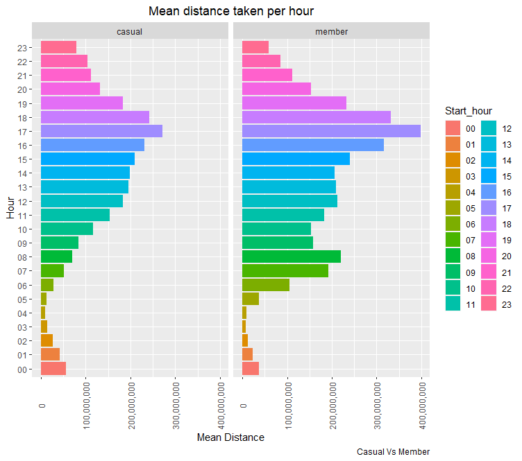

```r
#viz
     ggplot(year_2021_df_7, aes(y=start_hour, x = mean(distance), fill= start_hour))+
       geom_col()+
       labs(title = "Mean distance taken per hour",caption = "Casual Vs Member",y="Hour", x="Mean Distance")+
       theme(plot.title = element_text(hjust = 0.5), axis.text.x = element_text(angle = 90, vjust = 0.5))+ #centering the title
       scale_x_continuous(labels = scales :: comma)+ #removing the E expression
       scale_fill_discrete(name = "Start_hour")+ # to change the name of the legend
       facet_grid(~usertype)

     #ggsave("Plot20-Average distance taken per each hour in meters.png")
```

#### Start_timing

```r
#timing(total)
     year_2021_df_7 %>%
       group_by(start_timing) %>%
       summarize(mean(distance)) %>%
       print(n=24)
```

##### Results

```r
# A tibble: 4 × 2
  start_timing `mean(distance)`
  <chr>                   <dbl>
1 Afternoon               1522.
2 Evening                 1510.
3 Morning                 1506.
4 Night                   1489.
```

```r
#timing(user-type)
     year_2021_df_7 %>%
       group_by(usertype,start_timing) %>%
       summarize(mean(distance)) %>%
       print(n=24)
```

##### Results

```r
# A tibble: 8 × 3
# Groups:   usertype [2]
  usertype start_timing `mean(distance)`
  <chr>    <chr>                   <dbl>
1 casual   Afternoon               1598.
2 casual   Evening                 1570.
3 casual   Morning                 1576.
4 casual   Night                   1531.
5 member   Afternoon               1457.
6 member   Evening                 1466.
7 member   Morning                 1472.
8 member   Night                   1435.
```

##### Visualization

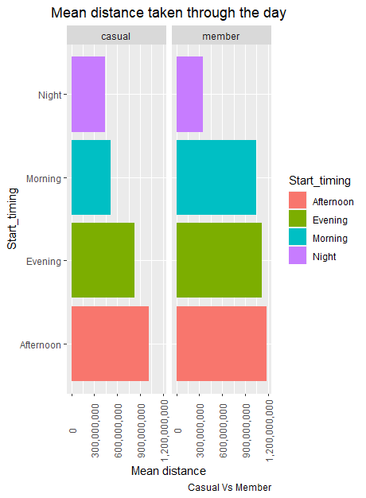

```r
#viz
     ggplot(year_2021_df_7, aes(y=start_timing, x = mean(distance), fill= start_timing))+
       geom_col()+
       labs(title = "Mean distance taken through the day",caption = "Casual Vs Member",y="Start_timing", x="Mean distance")+
       theme(plot.title = element_text(hjust = 0.5), axis.text.x = element_text(angle = 90, vjust = 0.5))+ #centering the title
       scale_x_continuous(labels = scales :: comma)+ #removing the E expression
       scale_fill_discrete(name = "Start_timing")+ # to change the name of the legend
       facet_grid(~usertype)
     #ggsave("Plot21-Average distance taken through the day.png")
```

#### Day

```r
#day(total)
     year_2021_df_7 %>%
       group_by(day_of_order) %>%
       summarize(mean(distance)) %>%
       print(n=24)
```

##### Results

```r
# A tibble: 7 × 2
  day_of_order `mean(distance)`
  <chr>                   <dbl>
1 Friday                  1495.
2 Monday                  1461.
3 Saturday                1580.
4 Sunday                  1567.
5 Thursday                1482.
6 Tuesday                 1471.
7 Wednesday               1487.
```

```r
#day(user-type)
     year_2021_df_7 %>%
       group_by(usertype,day_of_order) %>%
       summarize(mean(distance)) %>%
       print(n=24)
```

##### Results

```r
# A tibble: 14 × 3
# Groups:   usertype [2]
   usertype day_of_order `mean(distance)`
   <chr>    <chr>                   <dbl>
 1 casual   Friday                  1560.
 2 casual   Monday                  1507.
 3 casual   Saturday                1631.
 4 casual   Sunday                  1613.
 5 casual   Thursday                1549.
 6 casual   Tuesday                 1527.
 7 casual   Wednesday               1552.
 8 member   Friday                  1446.
 9 member   Monday                  1434.
10 member   Saturday                1516.
11 member   Sunday                  1511.
12 member   Thursday                1444.
13 member   Tuesday                 1442.
14 member   Wednesday               1453.
```

##### Visualization

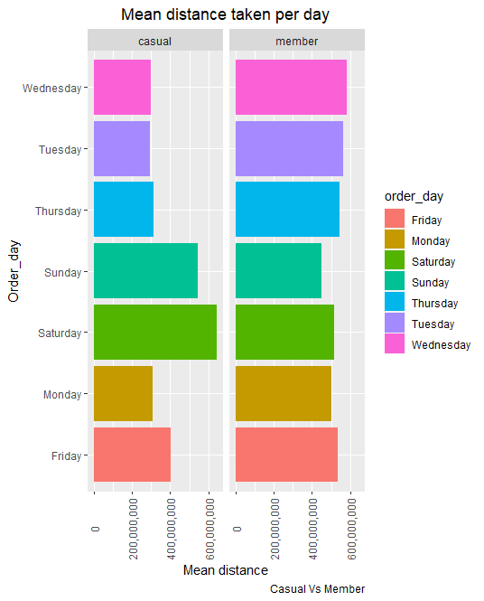

```r
#viz
     ggplot(year_2021_df_7, aes(y=day_of_order, x = mean(distance), fill= day_of_order))+
       geom_col()+
       labs(title = "Mean distance taken per day",caption = "Casual Vs Member",y="Order_day", x="Mean distance")+
       theme(plot.title = element_text(hjust = 0.5), axis.text.x = element_text(angle = 90, vjust = 0.5))+ #centering the title
       scale_x_continuous(labels = scales :: comma)+ #removing the E expression
       scale_fill_discrete(name = "order_day")+ # to change the name of the legend
       facet_grid(~usertype)
     #ggsave("Plot22-Average distance taken per the day.png")
```

#### Month

```r
#month(total)
     year_2021_df_7 %>%
       group_by(month) %>%
       summarize(mean(distance)) %>%
       print(n=24)
```

##### Results

```r
# A tibble: 12 × 2
   month     `mean(distance)`
   <chr>                <dbl>
 1 April                1502.
 2 August               1552.
 3 December             1354.
 4 February             1410.
 5 January              1374.
 6 July                 1563.
 7 June                 1557.
 8 March                1486.
 9 May                  1532.
10 November             1367.
11 October              1449.
12 September            1541.
```

```r
#month(user-type)
     year_2021_df_7 %>%
       group_by(usertype,month) %>%
       summarize(mean(distance)) %>%
       print(n=24)
```

##### Results

```r
# A tibble: 24 × 3
# Groups:   usertype [2]
   usertype month     `mean(distance)`
   <chr>    <chr>                <dbl>
 1 casual   April                1532.
 2 casual   August               1613.
 3 casual   December             1402.
 4 casual   February             1474.
 5 casual   January              1409.
 6 casual   July                 1602.
 7 casual   June                 1593.
 8 casual   March                1522.
 9 casual   May                  1557.
10 casual   November             1444.
11 casual   October              1532.
12 casual   September            1621.
13 member   April                1484.
14 member   August               1493.
15 member   December             1339.
16 member   February             1395.
17 member   January              1367.
18 member   July                 1521.
19 member   June                 1524.
20 member   March                1467.
21 member   May                  1511.
22 member   November             1338.
23 member   October              1396.
24 member   September            1472.
```

##### Visualization

[figure not shown]

**Average distance taken per month**

```r
#viz
     ggplot(year_2021_df_7, aes(y=month, x = mean(distance), fill= month))+
       geom_col()+
       labs(title = "Mean distance taken through the day",caption = "Casual Vs Member",y="month", x="Mean distance")+
       theme(plot.title = element_text(hjust = 0.5), axis.text.x = element_text(angle = 90, vjust = 0.5))+ #centering the title
       scale_x_continuous(labels = scales :: comma)+ #removing the E expression
       scale_fill_discrete(name = "month")+ # to change the name of the legend
       facet_grid(~usertype)
     ggsave("Plot23-Average distance taken per month.png")
```

#### Season

```r
#season(total)
     year_2021_df_7 %>%
       group_by(season) %>%
       summarize(mean(distance)) %>%
       print(n=24)
```

##### Results

```r
# A tibble: 4 × 2
  season `mean(distance)`
  <chr>             <dbl>
1 Autumn            1475.
2 Spring            1513.
3 Summer            1558.
4 Winter            1367.
```

```r
#season(user-type)
     year_2021_df_7 %>%
       group_by(usertype,season) %>%
       summarize(mean(distance)) %>%
       print(n=24)
```

##### Results

```r
# A tibble: 8 × 3
# Groups:   usertype [2]
  usertype season `mean(distance)`
  <chr>    <chr>             <dbl>
1 casual   Autumn            1568.
2 casual   Spring            1543.
3 casual   Summer            1603.
4 casual   Winter            1412.
5 member   Autumn            1414.
6 member   Spring            1492.
7 member   Summer            1513.
8 member   Winter            1355.
```

##### Visualization

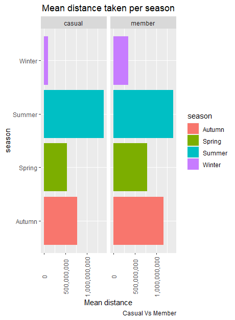

```r
 #viz
     ggplot(year_2021_df_7, aes(y=season, x = mean(distance), fill= season))+
       geom_col()+
       labs(title = "Mean distance taken per season",caption = "Casual Vs Member",y="season", x="Mean distance")+
       theme(plot.title = element_text(hjust = 0.5), axis.text.x = element_text(angle = 90, vjust = 0.5))+ #centering the title
       scale_x_continuous(labels = scales :: comma)+ #removing the E expression
       scale_fill_discrete(name = "season")+ # to change the name of the legend
       facet_grid(~usertype)
     #ggsave("Plot24-Average distance taken per season.png")
```

#### Year_Quarters

```r
#year_quarter(total)
     year_2021_df_7 %>%
       group_by(year_quarter) %>%
       summarize(mean(distance)) %>%
       print(n=24)
```

##### Results

```r
# A tibble: 4 × 2
  year_quarter `mean(distance)`
  <chr>                   <dbl>
1 Q1                      1447.
2 Q2                      1537.
3 Q3                      1552.
4 Q4                      1407.
```

```r
#year_quarter(user-type)
     year_2021_df_7 %>%
       group_by(usertype,year_quarter) %>%
       summarize(mean(distance)) %>%
       print(n=24)
```

##### Results

```r
# A tibble: 8 × 3
# Groups:   usertype [2]
  usertype year_quarter `mean(distance)`
  <chr>    <chr>                   <dbl>
1 casual   Q1                      1500.
2 casual   Q2                      1570.
3 casual   Q3                      1611.
4 casual   Q4                      1492.
5 member   Q1                      1427.
6 member   Q2                      1510.
7 member   Q3                      1495.
8 member   Q4                      1366.
```

##### Visualization

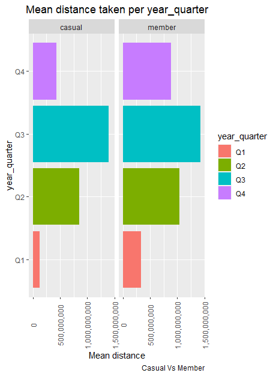

```r
#viz
     ggplot(year_2021_df_7, aes(y=year_quarter, x = mean(distance), fill= year_quarter))+
       geom_col()+
       labs(title = "Mean distance taken per year_quarter",caption = "Casual Vs Member",y="year_quarter", x="Mean distance")+
       theme(plot.title = element_text(hjust = 0.5), axis.text.x = element_text(angle = 90, vjust = 0.5))+ #centering the title
       scale_x_continuous(labels = scales :: comma)+ #removing the E expression
       scale_fill_discrete(name = "year_quarter")+ # to change the name of the legend
       facet_grid(~usertype)
     #ggsave("Plot25-Average distance taken per year_quarter.png")
```

#### From_Station

```r
#station (total)
     year_2021_df_7 %>%
       group_by(from_station_name) %>%
       summarize(mean(distance)) %>%
       print(n=1000)
```

##### Results

```r
# A tibble: 836 × 2
   from_station_name          `mean(distance)`
   <chr>                                 <dbl>
 1 2112 w peterson ave                   1848.
 2 63rd st beach                         2548.
 3 900 w harrison st                     1351.
 4 aberdeen st & jackson blvd            1490.
 5 aberdeen st & monroe st               1984.
 6 aberdeen st & randolph st             1724.
 7 ada st & 113th st                     1256.
 8 ada st & washington blvd              2060.
 9 adler planetarium                     1954.
10 albany ave & 26th st                  3469.
# … with 826 more rows
# ℹ Use `print(n = ...)` to see more rows
```

```r
#station (user-type)
     year_2021_df_7 %>%
       group_by(usertype,from_station_name) %>%
       summarize(mean(distance)) %>%
       print(n=2000)
```

##### Results

```r
# A tibble: 1,637 × 3
# Groups:   usertype [2]
   usertype from_station_name          `mean(distance)`
   <chr>    <chr>                                 <dbl>
 1 casual   2112 w peterson ave                   2028.
 2 casual   63rd st beach                         2395.
 3 casual   900 w harrison st                     1494.
 4 casual   aberdeen st & jackson blvd            1659.
 5 casual   aberdeen st & monroe st               2237.
 6 casual   aberdeen st & randolph st             1985.
 7 casual   ada st & 113th st                     1882.
 8 casual   ada st & washington blvd              2142.
 9 casual   adler planetarium                     1889.
10 casual   albany ave & 26th st                  3281.
# … with 1,627 more rows
# ℹ Use `print(n = ...)` to see more rows
```

##### Visualization

```r
#viz
#Create a data set with top5 start point per each user-type
     top_10_avg_dist <-year_2021_df_7 %>%
       group_by(usertype, from_station_name) %>%
       summarise(mean(distance))
     top_10_avg_dist<-top_10_avg_dist[order(-top_10_avg_dist$`mean(distance)`),]#add the , to the end
     top_10_avg_dist<-top_10_avg_dist %>%
       group_by(usertype) %>%
       slice_head(n=5)
```

##### Results

```r
# A tibble: 10 × 3
# Groups:   usertype [2]
   usertype            from_station_name mean(distance)
1    casual          tripp ave & 15th st      10721.571
2    casual       komensky ave & 31st st       8933.972
3    casual             nordica & medill       7762.697
4    casual narragansett ave & school st       7512.171
5    casual     w 103rd st & s avers ave       7466.370
6    member major ave & bloomingdale ave      13762.520
7    member             sayre & diversey      13690.804
8    member      francisco ave & 47th st      12500.280
9    member        long ave & belden ave      11327.120
10   member     central ave & madison st      11199.833
```

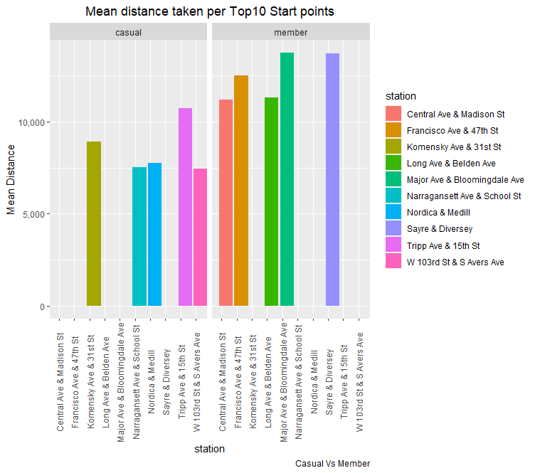

**Average distance taken per Top10 Start points**

```r
#Visualization
ggplot(top_10_average, aes(y=top_10_avg_dist$`mean(distance)`, x=top_10_avg_dist$from_station_name, fill = top_10_avg_dist$from_station_name))+
       geom_col(position = position_nudge(x=0.3))+
       labs(title = "Mean distance taken per Top10 Start points",caption = "Casual Vs Member",x="station", y="Mean Distance")+
       theme(plot.title = element_text(hjust = 0.5), axis.text.x = element_text(angle = 90, vjust = 0.5))+ #centering the title
       scale_y_continuous(labels = scales :: comma)+ #removing the E expression
       scale_fill_discrete(name = "station")+ # to change the name of the legend
       facet_grid(~usertype)

     #ggsave("Plot26-Average distance taken per Top10 Start points.png")
```

#### Focused results on the user-types’ behavior

This excel sheet contains a summarized analysis of casual and member behavior through different times, hours, days, months, seasons, and year quarters. It also shows the different stations, most trips started and ended, most taken routes, and the type of the bikes used. It also has the average duration and distance taken at different states. This worksheet can be observed through this link: [Summary Analysis of the behavior between casual and member worksheet](https://docs.google.com/spreadsheets/d/1_pUIYTEovlK3QhIDuw2c_U5N1GEPjFAk/edit?usp=sharing&ouid=104718905829386398715&rtpof=true&sd=true)

#### Dashboard of the data-set to test different factors

This dashboard was founded to summarize and integrate the analysis. Also, It is working a real time dashboard that can assist i further analysis. It contains both the count of the trips, and average time duration and distance. It can be observed through this link:[Tableau Dashboards](https://public.tableau.com/app/profile/sara.samy/viz/Cyclistbikeshareapp2021/Countofthetripsthroughdifferentfactors#1) or by clicking on that image below.

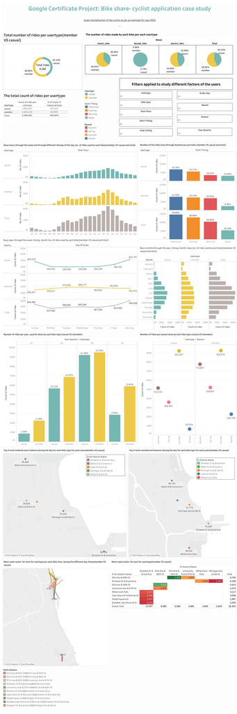

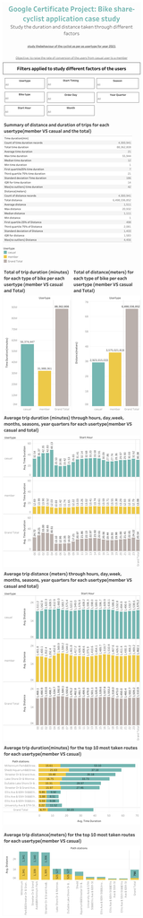

#### Deep observations on casuals’ behavior

1. At mornings, **18.33%** Of the casuals, **11** is considered the peak hour, Average duration is **27** minutes and distance is **1576** meters, classic bike is the most used, stop and start stations are **Streeter Dr & Grand Ave**, and the top most taken route is **“DuSable Lake Shore Dr & Monroe St To Streeter Dr & Grand”**.
2. At Afternoons(highest timing through the day), **%36.30** Of the casuals, **16** is considered the peak hour, Average duration is **32** minutes and distance is **1598** meters, classic bike is the most used, stop and start stations are **Streeter Dr & Grand Ave**, and the top most taken route is **“Shedd Aquarium To Streeter Dr & Grand Ave”**.
3. At Evenings, **29.57%** Of the casuals, **17** is considered the peak hour, Average duration is **28** minutes and distance is **1570** meters, classic bike is the most used, stop and start stations are **Streeter Dr & Grand Ave**, and the top most taken route is **“Streeter Dr & Grand Ave To Millennium Park”**.
4. At Nights, **15.80%** Of the casuals, **21** is considered the peak hour, Average duration is **33** minutes and distance is **1531** meters, classic bike is the most used, Docked bikes had the most usage percent, stop and start stations are **Streeter Dr & Grand Ave** and **Wells St & Concord Ln** simultaneously, and the top most taken route is **“Ellis Ave & 55th St&&Ellis Ave & 60th St”**.
5. Weekdays are all on average of **10-11%** of casuals but become higher on Fridays **14.37%**, while weekends are almost double the weekdays percentage, the highest on Saturdays.
6. Winter is the least season from the number of rides. December is considered to be the peak month. The top most taken route is **“DuSable Lake Shore Dr & Monroe St To Streeter Dr & Grand”**.
7. Summer is the top season from the number of rides. July is considered to be the peak month. The top most taken route is **“Lake Shore Dr & Monroe St To Streeter Dr & Grand Ave”**.
8. Spring is the second-placed season from the number of rides. May is considered to be the peak month. The top most taken route is **“Lake Shore Dr & Monroe St To Streeter Dr & Grand Ave”**.
9. Fall is the third-placed season from the number of rides. September is considered to be the peak month. The top most taken route is **“DuSable Lake Shore Dr & Monroe St To Streeter Dr & Grand Ave”**.
10. Docked bikes record a percentage of usage higher than that of the members.

#### Conclusions

- Number of classic bikes should increase specially in Summer at July.
- More bikes could be added at Streeter Dr & Grand Ave station.
- Afternoons and Evenings also needed more bikes to avoid any lack of service.
- Docked bikes should increase.
- Lake and park streets should be considered.